# Презентация по лабораторной работе №8

Реализация основных моделей в дискретно-событийном подходе

Люпп Софья Романовна

1132236039@rudn.ru

Российский университет дружбы народов

2026-05-30

# Информация

## Докладчик

- Люпп Софья Романовна
- студентка НКНбд-01-23
- кафедра теории вероятностей и кибербезопасности
- Российский университет дружбы народов им. П. Лумумбы
- 1132236039@rudn.ru
- https://github.com/srluipp

# Вводная часть

## Актуальность

Дискретно-событийный подход позволяет моделировать стохастические процессы с учетом случайности заражений, что важно для оценки рисков и планирования мер вмешательства для различных эпидемий, что особенно актуально после недавнего COVID-19

## Объект и предмет исследования

Объект исследования: дискретно-событийное моделирование Предмет исследования: модель SIR

## Цели

Изучить дискретно-событийный подход к имитационному моделированию на примере классической модели распространения инфекции SIR.

## Задачи

1. Изучить теорию по дискретно-событийному моделированию;
2. Создать необходимые скрипты по заданию;
3. Выполнить дополнительные задания;
4. Выполнить отчет и презентацию, преобразовать документацию в формате Quarto и выполнить литературный код.

## Материалы и методы

В качестве материалов к выполнению лабораторной работы была использована работа Имитационное моделирование. Практикум. (А. В. Королькова Кулябов Д. С.)

# Выполнение работы

Реализую модель sir_des.jl. Вывожу полученные результаты для всех трех групп инфецированных (рис. 1).

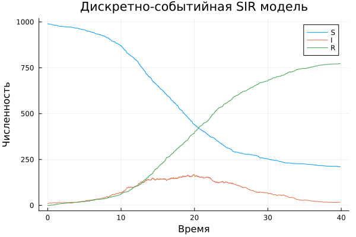

Рисунок 1: sir_des.jl

## Beta=0.03

Провожу анализ цикла, варьирующего параметры бета, получаю три результата для трех разных значений (рис. 2)

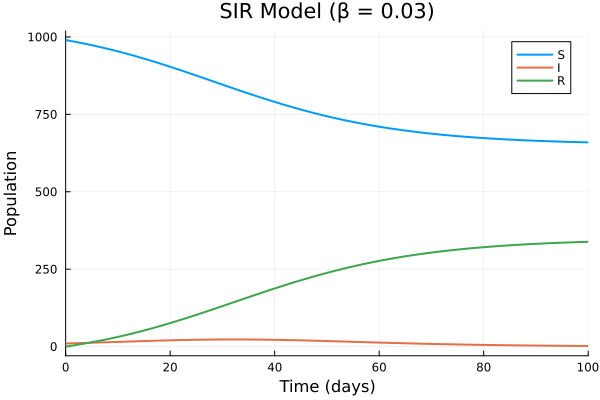

Рисунок 2: Бета=0.03

## Beta=0.05

(рис. 3).

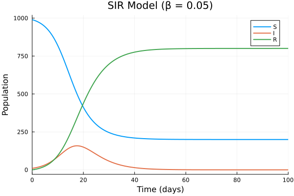

Рисунок 3: Бета=0.05

## Beta=0.07

(рис. 4).

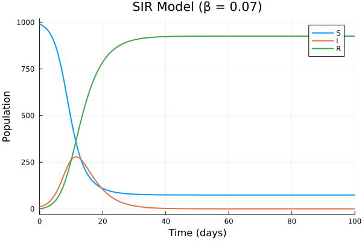

Рисунок 4: Бета=0.07

## Замена времени выздоравления на 1/γ

Заменяю экспоненциальное время выздоровления на фиксированную величину 1/γ и получаю результаты для графика sir_des.jl (рис. 5).

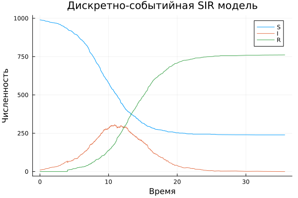

Рисунок 5: sir_des.jl с фикс величиной

(рис. 6).

[figure not shown]

(рис. 7).

[figure not shown]

(рис. 8).

[figure not shown]

## Время выполнения sir_run для популяции 10000 индивидов

С помощью макроса @benchmark измеряю время выполнения sir_run (рис. 9)

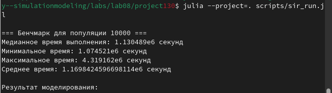

Рисунок 9: Бенчмарк

## Время выполнения sir_run для популяции 10000 индивидов

(рис. 10).

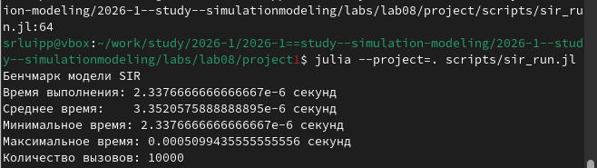

Рисунок 10: Бенчмарк

## CVS-результаты

Сохраняю результаты в формате csv (рис. 11)

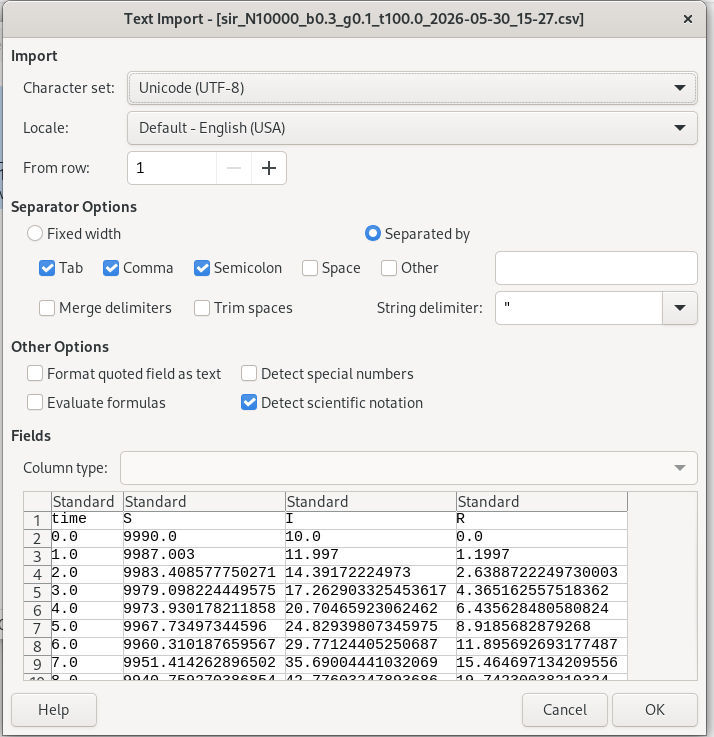

Рисунок 11: csv

## CVS-результаты

Сохраняю результаты в формате csv (рис. 12)

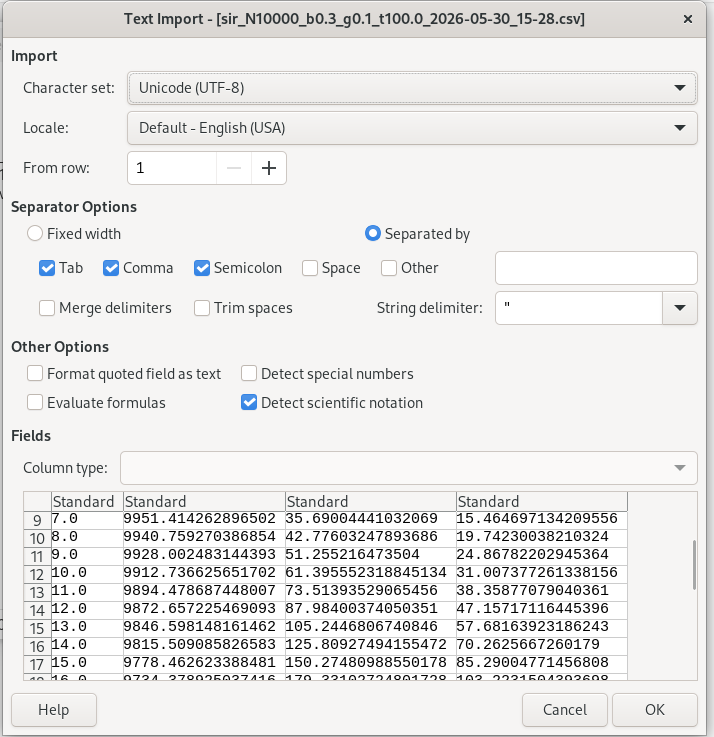

Рисунок 12: csv

## Модель SIR с демографией

Добавляю демографические события: расширяю модель, добавив в жизненный цикл индивида возможность смерти (с постоянной интенсивностью μ) и рождение новых восприимчивых (рис. 13).

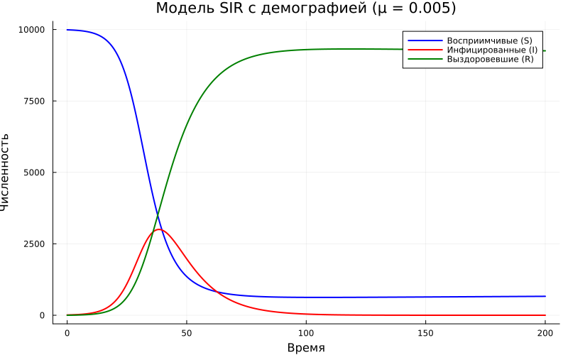

Рисунок 13: Модель SIR с демографией

## Модель SIR с вакцинацией

В функцию live добавить блок ожидания смерти. Реализовываю стратегию вакцинации: в определённый момент времени (или при превышении порога инфицированных) часть восприимчивых мгновенно переводится в :R. Исследую, какая доля вакцинированных необходима для предотвращения эпидемии (рис. 14)

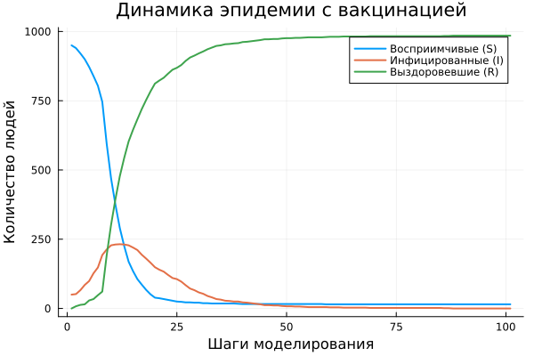

Рисунок 14: Модель SIR с вакцинацией

## Анализ модели SIR с вакцинацией

(рис. 15).

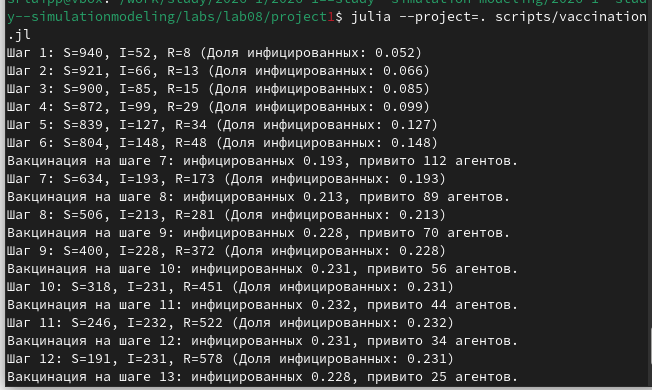

Рисунок 15: Анализ

## Срабатывание события вакцинации по таймеру

Добавляю в модель срабатывание события вакцинации по таймеру (рис. 16).

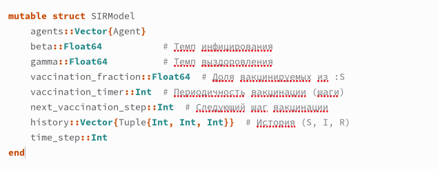

Рисунок 16: срабатывание события вакцинации по таймеру

## Латентный период

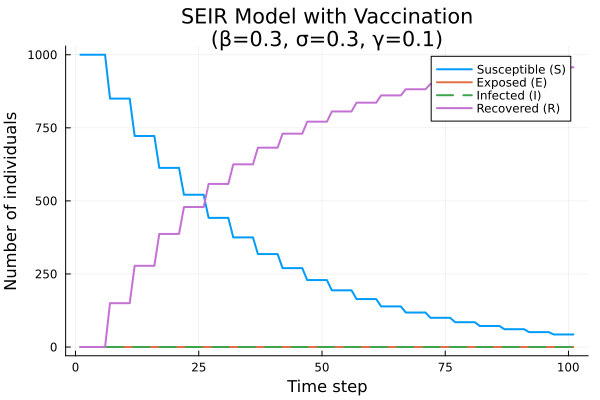

Рисунок 17: Латентный период

## Результаты

Результатами данной лабораторной работы являются получившиеся графики и анимация в plots

## Итоговый слайд

(рис. 18).

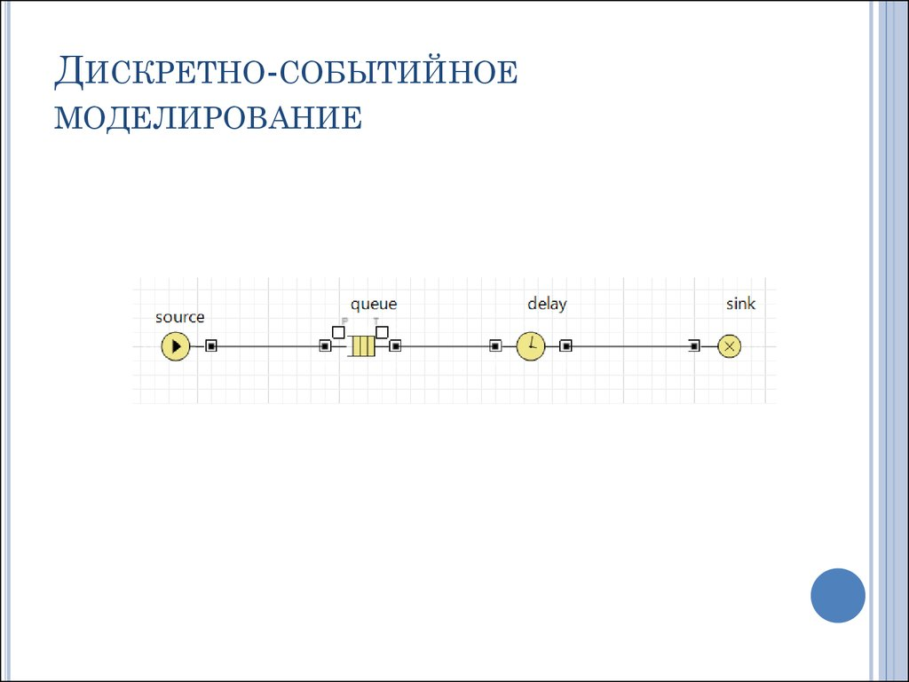

Рисунок 18: Дискретно-событийное моделирование